# Price Prediction - Airbnb Apartments in Milan

## 3.9 Are there any differences in availability between the different areas?

### by region

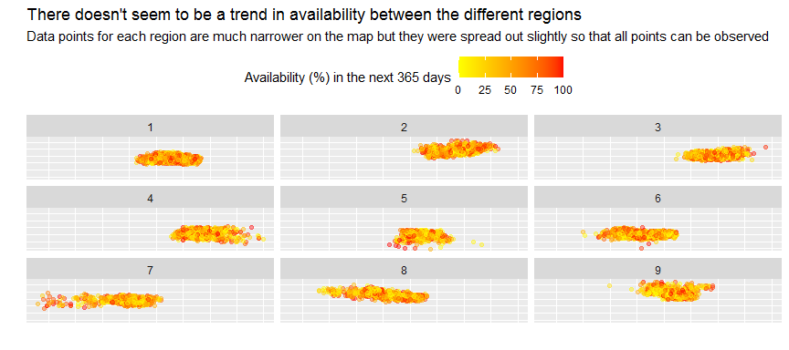

```r
ggplot(raw_data, aes(longitude, latitude)) +
  geom_jitter(aes(colour = availability_365_perc), alpha = 0.4, width = 0.01, height = 0.01)+
  labs(x="",
       y="",
       col = "Availability (%) in the next 365 days",
       title="There doesn't seem to be a trend in availability between the different regions",
       subtitle = "Data points for each region are much narrower on the map but they were spread out slightly so that all points can be observed")+
  scale_colour_gradient(low = "yellow", high = "red")+
  facet_wrap(.~Region)+
  theme(axis.ticks.y = element_blank(),axis.text.y = element_blank(),
        axis.ticks.x = element_blank(),axis.text.x = element_blank(),
        legend.position = "top")
```

### by zipcode quintile group

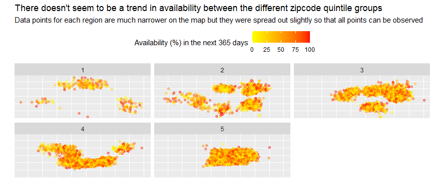

```r
ggplot(raw_data, aes(longitude, latitude)) +
  geom_jitter(aes(colour = availability_365_perc), alpha = 0.4, height = 0.01, width = 0.01)+
  labs(x="",
       y="",
       col = "Availability (%) in the next 365 days",
       title="There doesn't seem to be a trend in availability between the different zipcode quintile groups",
       subtitle = "Data points for each region are much narrower on the map but they were spread out slightly so that all points can be observed")+
  scale_colour_gradient(low = "yellow", high = "red")+
  facet_wrap(.~zipcode_quantile_group)+
  theme(axis.ticks.y = element_blank(),axis.text.y = element_blank(),
        axis.ticks.x = element_blank(),axis.text.x = element_blank(),
        #plot.title = element_text(lineheight=.8, face="bold", vjust=1),
        legend.position = "top")
```

## 3.10 What does the aggregated availability look like over 365 days?

### by region

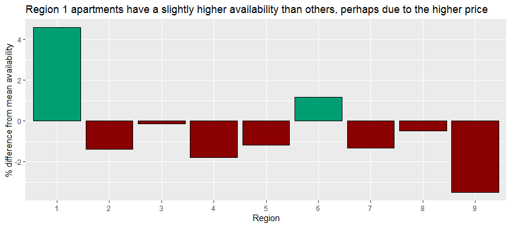

```r
data_availability_by_region <- raw_data%>%
  group_by(Region)%>%
  summarize(count = n(),
            availability = (sum(availability_365)/count)/365*100,
            diff_from_mean = availability - mean(raw_data$availability_365_perc))

ggplot(data = data_availability_by_region, aes(Region, diff_from_mean, fill = diff_from_mean >= 0))+
        geom_col(col = "black")+
        scale_fill_manual(values = c("dark red", "#009E73"))+
        labs(y = "% difference from mean availability",
             x = "Region",
             title = "Region 1 apartments have a slightly higher availability than others, perhaps due to the higher price")+
        theme(legend.position = "none")
```

### by Zipcode Quantile Group

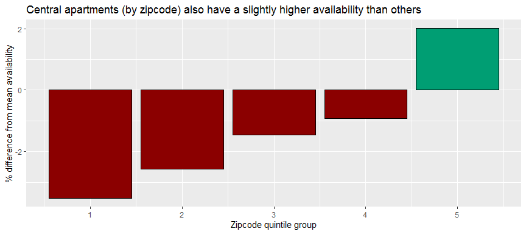

```r
data_availability_by_zipcode_quantile_group <- raw_data %>%
  group_by(zipcode_quantile_group) %>%
  summarize(count = n(),
            availability = (sum(availability_365)/count)/365*100,
            diff_from_mean = availability - mean(raw_data$availability_365_perc))

ggplot(data = data_availability_by_zipcode_quantile_group, aes(zipcode_quantile_group, diff_from_mean, fill = diff_from_mean >= 0))+
        geom_col(col = "black")+
        scale_fill_manual(values = c("dark red", "#009E73"))+
        labs(y = "% difference from mean availability",
             x = "Zipcode quintile group",
             title = "Central apartments (by zipcode) also have a slightly higher availability than others")+
        theme(legend.position = "none")
```

## 3.11 What type of extra services are available during an Airbnb stay in Milan?

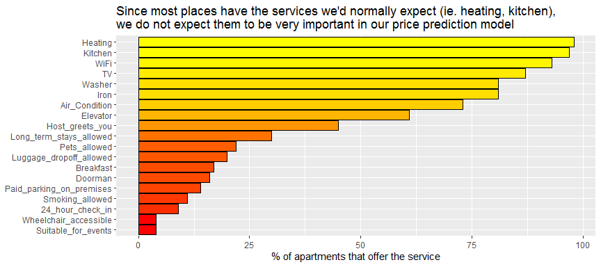

```r
data_Extras <- raw_data %>%
  select(TV:"24_hour_check_in")%>%
  gather("Extras", "Status")%>%
  group_by(Extras)%>%
  summarize(Count = n(),
            Availability = round(sum(Status)/Count,2)*100)%>%
  mutate(Extras = fct_reorder(Extras, Availability))

ggplot(data_Extras, aes(Extras, Availability))+
  geom_col(aes(fill=Availability), col = "black")+
  scale_fill_gradient(low="red", high="yellow")+
  theme(legend.position = "none")+
  labs(x=NULL,
       y= "% of apartments that offer the service",
       title = "Since most places have the services we'd normally expect (ie. heating, kitchen), \nwe do not expect them to be very important in our price prediction model")+
  coord_flip()
```

## 3.12 Are there any differences in survey ratings?

### Fullscale (0-100)

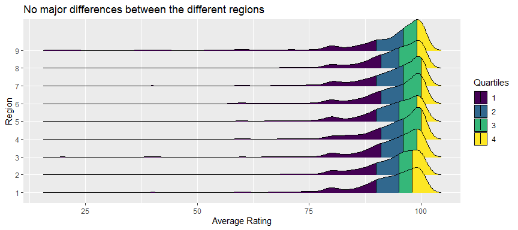

```r
ggplot(raw_data, aes(review_scores_rating, Region, fill = factor(stat(quantile)))) +
  stat_density_ridges(
    geom = "density_ridges_gradient", calc_ecdf = TRUE,
    quantiles = 4, quantile_lines = TRUE) +
  labs(x = "Average Rating",
       title = "No major differences between the different regions")+
  scale_fill_viridis_d(name = "Quartiles")
```

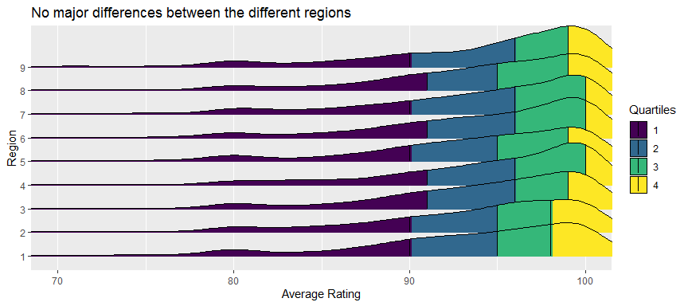

```r
ggplot(raw_data, aes(review_scores_rating, Region, fill = factor(stat(quantile)))) +
  stat_density_ridges(
    geom = "density_ridges_gradient", calc_ecdf = TRUE,
    quantiles = 4, quantile_lines = TRUE) +
  scale_fill_viridis_d(name = "Quartiles")+
  labs(title = "No major differences between the different regions",
       x= "Average Rating")+
  coord_cartesian(xlim = c(70,100))
```

# 4 Regression Model

## 4.1 Prepare our model

We need to remove the variables that were related to the price (ie. cleaning_fee_perc and security_perc) as well as the ones that are simply variations of another variable (ie. we shouldn’t keep both absolute availability and relative availability due to multicollinearity).

```r
# Set seed for reproducibility
set.seed(123)

#might want to take these out if we use the perc values
raw_data_model <- raw_data %>%
  select (-availability_30, -availability_60, -availability_90, -availability_365,
          -id, -host_id,
          -cleaning_fee_perc, -security_deposit_perc,
          -cleaning_fee, -security_deposit, -daily_price,
          -zipcode_quantile_count, -zipcode_quantile_price)%>%
  filter (total_price <= quantile(raw_data$total_price, probs = c(0.98)))
```

We’ve seen that while most of the data is under $400 (>98%), there are some extreme outliers up to $3,000 that might affect our model. To improve the accuracy of our model, we can **remove the highest 2% of the prices** as we do not want to tailor this model to the luxury market for a couple reasons:

- if you’re a tourist, you’re unlikely to check online prices if you can even consider paying ~$3,000 a night
- similarly, as a landlord of a luxury property, you probably don’t need to compare your price to others’
- there is very limited data
- Airbnb’s target market isn’t focused on luxurious escapes

## 4.2 Data split

Let’s split the dataset into the following:

- a train dataset of 75% of the raw data to train our prediction model on
- a test dataset of 25% of the raw data to then test it on

```r
split <- createDataPartition(raw_data_model$total_price,
                             times = 1,
                             p =0.75,
                             list = FALSE)

train_data <- raw_data_model[split,]
test_data <- raw_data_model[-split,]


y <- train_data$total_price
```

## 4.3 Pre-processing

Let’s use some basic standardisation offered by the caret package such as **centering** (subtract mean from values) and **scaling** (divide values by standard deviation).

```r
#take out price temporarily as we do not want this to be processed
train_data <- train_data %>%
  select (-total_price)

#center and scale our data
preProcess_range_model <- preProcess(train_data, method=c("center", "scale"))

train_data <- predict(preProcess_range_model, newdata = train_data)
test_data <- predict(preProcess_range_model, newdata = test_data)

#Append the Y variable back on with original values
train_data$total_price <- y
```

## 4.4 Resampling

We will perform a 10-fold Cross Validation 5 times. This means we will be dividing the training dataset randomly into 10 parts, use each of the 10 parts as a “testing dataset” for the model and “train” on the remaining 9.

Essentially, we are “pretending” that some of our data is new and use the rest of the data to model on. We then take the average error of each of the 10 models and repeat this process 5 times. Doing it more than once will give a more realistic sense of how the model will perform on new data.

```r
train.control <- trainControl(method = "repeatedcv",
                              number = 10, #10
                              repeats = 5, #5
                              search = "random")

clusters <- 4
```

## 4.5 Model 1 - Stepwise Regression

```r
#run them all in paralel
cl <- makeCluster(clusters, type = "SOCK")

#register cluster train in paralel
registerDoSNOW(cl)

#train model
step_model <- train(total_price ~ .,
                  data = train_data,
                  method = "lmStepAIC",
                  trControl = train.control)

#shut the instances of R down
stopCluster(cl)
```

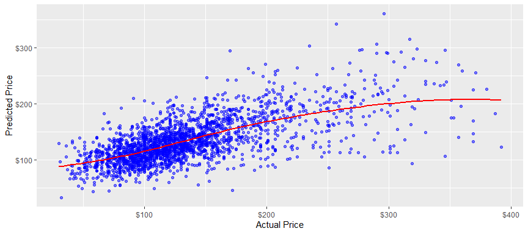

```r
#get predictions
predictions <- predict(step_model, test_data)

#create dataset
test_data2 <- test_data %>%
  mutate(predicted_total_price = predictions,
         actual_total_price = total_price,
         Residuals = predicted_total_price - actual_total_price)%>%
  select(predicted_total_price, actual_total_price, Residuals)

#visualise
ggplot(test_data2, aes(actual_total_price, predicted_total_price))+
  geom_point(alpha = 0.5, color = "blue")+
  geom_smooth(method = "loess", col = "red", se = FALSE)+
  scale_x_continuous(labels = dollar_format())+
  scale_y_continuous(labels = dollar_format())+
  labs(x = "Actual Price",
       y = "Predicted Price")
```

## 4.6 Model 2 - Gradient Boosting Machine

```r
#run them all in paralel
cl <- makeCluster(clusters, type = "SOCK")

#register cluster train in paralel
registerDoSNOW(cl)

#train model
gbm_model <- train(total_price ~ .,
                  data = train_data,
                  method = "gbm",
                  trControl = train.control)

#shut the instances of R down
stopCluster(cl)

#show model
gbm_model$results
```

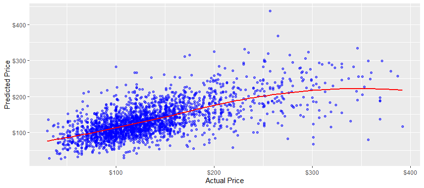

```r
#get predictions
predictions <- predict(gbm_model, test_data)

#create dataset
test_data2 <- test_data %>%
  mutate(predicted_total_price = predictions,
         actual_total_price = total_price,
         Residuals = predicted_total_price - actual_total_price)%>%
  select(predicted_total_price, actual_total_price, Residuals)

#visualise
ggplot(test_data2, aes(actual_total_price, predicted_total_price))+
  geom_point(alpha = 0.5, color = "blue")+
  geom_smooth(method = "loess", col = "red", se = FALSE)+
  scale_x_continuous(labels = dollar_format())+
  scale_y_continuous(labels = dollar_format())+
  labs(x = "Actual Price",
       y = "Predicted Price")
```

## 4.7 Model 3 - Random Forrest

```r
#run them all in paralel
cl <- makeCluster(clusters, type = "SOCK")

#register cluster train in paralel
registerDoSNOW(cl)

#train model
rf_model <- train(total_price ~ .,
                  data = train_data,
                  method = "rf",
                  trControl = train.control)

#shut the instances of R down
stopCluster(cl)
```

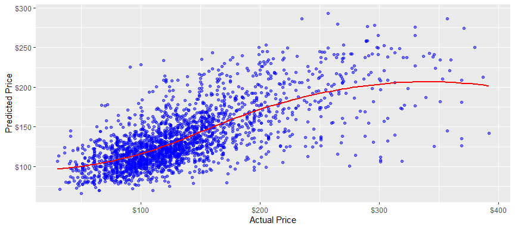

```r
#get predictions
predictions <- predict(rf_model, test_data)

#create dataset
test_data2 <- test_data %>%
  mutate(predicted_total_price = predictions,
         actual_total_price = total_price,
         Residuals = predicted_total_price - actual_total_price)%>%
  select(predicted_total_price, actual_total_price, Residuals)

#visualise
ggplot(test_data2, aes(actual_total_price, predicted_total_price))+
  geom_point(alpha = 0.5, color = "blue")+
  geom_smooth(method = "loess", col = "red", se = FALSE)+
  scale_x_continuous(labels = dollar_format())+
  scale_y_continuous(labels = dollar_format())+
  labs(x = "Actual Price",
       y = "Predicted Price")
```

## 4.8 Compare the three Models

```r
model_list <- list(lm = step_model, gbm = gbm_model, rf = rf_model)

model_comparison <- resamples(model_list)

summary(model_comparison)
```

```
##
## Call:
## summary.resamples(object = model_comparison)
##
## Models: lm, gbm, rf
## Number of resamples: 50
##
## MAE
##         Min.  1st Qu.   Median     Mean  3rd Qu.     Max. NA's
## lm  28.80662 30.42014 30.96066 31.12278 31.77723 33.78264    0
## gbm 29.65224 31.00173 31.95126 31.77072 32.51935 34.16346    0
## rf  26.30958 28.92319 29.66106 29.47589 30.19024 31.02886    0
##
## RMSE
##         Min.  1st Qu.   Median     Mean  3rd Qu.     Max. NA's
## lm  39.95224 42.48382 43.97251 43.97613 45.40242 49.86685    0
## gbm 40.63586 43.53866 44.30020 44.43717 45.74549 49.34192    0
## rf  36.95195 40.98212 42.20428 41.98914 43.28350 46.51561    0
##
## Rsquared
##          Min.   1st Qu.    Median      Mean   3rd Qu.      Max. NA's
## lm  0.3682906 0.4035622 0.4303998 0.4326528 0.4541365 0.5126889    0
## gbm 0.3694281 0.4216419 0.4480919 0.4469149 0.4736226 0.5268891    0
## rf  0.4010818 0.4607834 0.4839766 0.4860365 0.5164107 0.5429325    0
```

We can see that the Random Forrest is the most optimal model across the range of our data due to:

- the best (lowest) Mean Absolute Error (MAE) and Root Mean Square Error (RMSE)
- the best (highest) coefficient of determinaton (Rsquared)

We can also compare the models quantitatively and see if the results of the Random Forrest model is significantly better than the other two.

**Random Forrest versus Stepwise Regression:**

```r
compare_models(rf_model, step_model)
```

```
##
##  One Sample t-test
##
## data:  x
## t = -4.7554, df = 49, p-value = 1.78e-05
## alternative hypothesis: true mean is not equal to 0
## 95 percent confidence interval:
##  -2.826667 -1.147312
## sample estimates:
## mean of x
##  -1.98699
```

**Random Forrest versus Gradient Boosting Machine:**

```r
compare_models(rf_model, gbm_model)
```

```
##
##  One Sample t-test
##
## data:  x
## t = -6.0969, df = 49, p-value = 1.659e-07
## alternative hypothesis: true mean is not equal to 0
## 95 percent confidence interval:
##  -3.254921 -1.641147
## sample estimates:
## mean of x
## -2.448034
```

These results also confirm that the Random Forrest model is significantly better than the other two.

## 4.9 How many predictors did the most optimal model have?

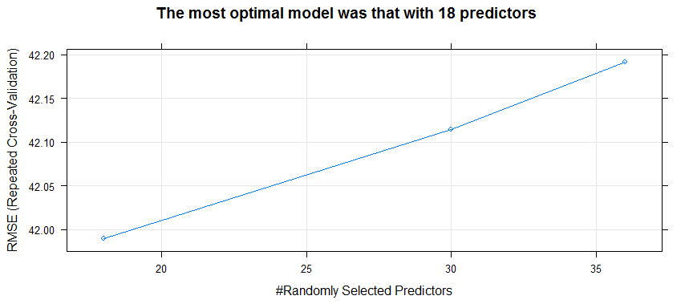

```r
plot(rf_model,
     main = "The most optimal model was that with 18 predictors")
```

## 4.10 What were the most important variables?

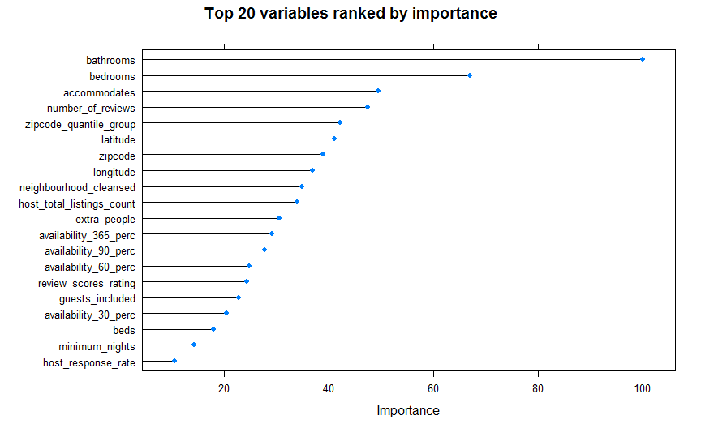

```r
imp <- varImp(rf_model)

plot(imp, top = 20,
     main = "Top 20 variables ranked by importance")
```

We can see that the most important factors were:

- the number of **bathrooms**
- the number of **bedrooms**
- the number of people it **accommodates**
- the **zipcode_quantile_group** (rather than region)

On large, these shouldn’t come as a surprise, as we expect location and the number of people it accommodates to be somwhere at the top.

It might be surprising, though, that the number of bathrooms was more important than the number of bedrooms. However, it could be that the number of bathrooms represents a more accurate way to track the size of the property. For example, it is common for landlords to construct 4 bedrooms out of a 2 bedroom apartment in order to increase revenue but not many artificially increase the number of bathrooms.

In other words, an apartment with 6 bedrooms is not necessarily very large, as it could be due to the fact that each room was split into two. However, chances are that if an apartment has 6 bathrooms, it is quite large! We’ve also seen this in the correlation plot, where there was a higher correlation between the average price and number of bathrooms than between the average price and number of bedrooms.

## 4.11 Visualising the distribution of residuals (prediction error)

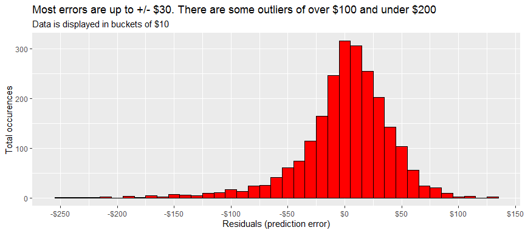

```r
ggplot(test_data2, aes(Residuals))+
  geom_histogram(binwidth = 10,col = "black", fill = "red")+
  scale_x_continuous(labels = dollar_format(), n.breaks = 10)+
  labs(x="Residuals (prediction error)",
       y= "Total occurences",
       title = "Most errors are up to +/- $30. There are some outliers of over $100 and under $200",
       subtitle = "Data is displayed in buckets of $10")
```

## 4.12 Visualising the Random Forrest Model

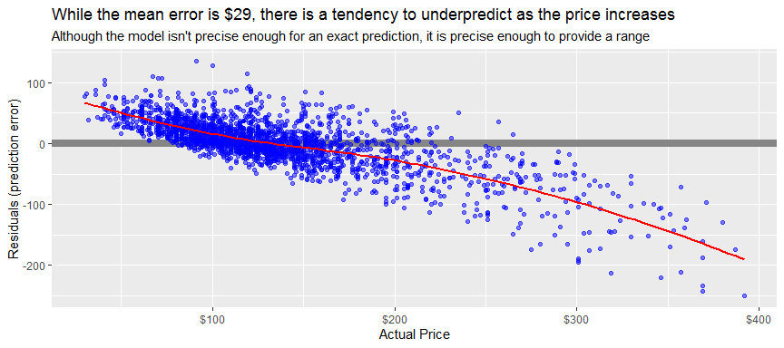

```r
#get predictions
predictions <- predict(rf_model, test_data)

#create dataset
test_data2 <- test_data %>%
  mutate(predicted_total_price = predictions,
         actual_total_price = total_price,
         Residuals = predicted_total_price - actual_total_price)%>%
  select(predicted_total_price, actual_total_price, Residuals)

#visualise
ggplot(test_data2, aes(actual_total_price, Residuals))+
  geom_hline(yintercept = 0, size = 3, color = "grey52")+
  geom_point(alpha = 0.5, color = "blue")+
  geom_smooth(method = "loess", col = "red", se = FALSE)+
  scale_x_continuous(labels = dollar_format())+
  labs(title = "While the mean error is $29, there is a tendency to underpredict as the price increases",
       subtitle = "Although the model isn't precise enough for an exact prediction, it is precise enough to provide a range",
       x = "Actual Price",
       y="Residuals (prediction error)")
```

## 4.13 Potential reasons for the “medium” Rsquared:

- the size of the apartment (squared feet/meters) is not included in the dataset and thus, in the model; this metric might be a better predictor than the number of bedrooms/bathrooms
- any special characteristics of an apartment (ie. view of the popular Cathedral, situated in a popular square, in a historic building, etc)
- human behaviour/decision making is known to be hard to predict accurately
- pictures of the property not included/assessed - when was the last time we booked an apartment without seeing a picture?
- on top of pictures, we might also be influenced (positively or negatively) by the message within the property listing written by the landlord which this dataset does not account for

## 4.14 How can we improve on this project?

- build a dashboard that would inform potential landlords of what price range to use based on their inputs
- pull data from a different period of the year, as we know prices are seasonal
- look at other types of accommodation, as this dataset only includes apartments
- work upon the data limitations mentioned above which affected the Rsquared